# TFCB2020 Capstone Project

BrendanMcShane

12/16/2020

Question 3:Which continuous variables are the most correlated, and to what extent? Do these correlations change after subsetting by disease state?

```r
df <- read.csv(file = 'data/ds_whole.csv')
#Read in the data
df_cont <- df[, c(3,4,5,6,8,9)]
#Subset to the continuous variables
df_cont_corr <- cor(df_cont)
#Using the cor() function from corrplot to generate correlation coefficients for each pair of variables
knitr::kable(df_cont_corr)
```

|  | age | ocular_pressure | mean_deviation | pattern_standard_deviation | cornea_thickness | RNFL4.mean |
| --- | --- | --- | --- | --- | --- | --- |
| age | 1.0000000 | 0.1145895 | -0.3262391 | 0.1509077 | -0.0178414 | -0.2702885 |
| ocular_pressure | 0.1145895 | 1.0000000 | -0.4492748 | 0.2625536 | -0.0267667 | -0.4744526 |
| mean_deviation | -0.3262391 | -0.4492748 | 1.0000000 | -0.5297177 | 0.2028142 | 0.6792458 |
| pattern_standard_deviation | 0.1509077 | 0.2625536 | -0.5297177 | 1.0000000 | -0.1386938 | -0.6041791 |
| cornea_thickness | -0.0178414 | -0.0267667 | 0.2028142 | -0.1386938 | 1.0000000 | 0.1745266 |
| RNFL4.mean | -0.2702885 | -0.4744526 | 0.6792458 | -0.6041791 | 0.1745266 | 1.0000000 |

```r
#make a well-formatted table of the calculated correlation coefficients
```

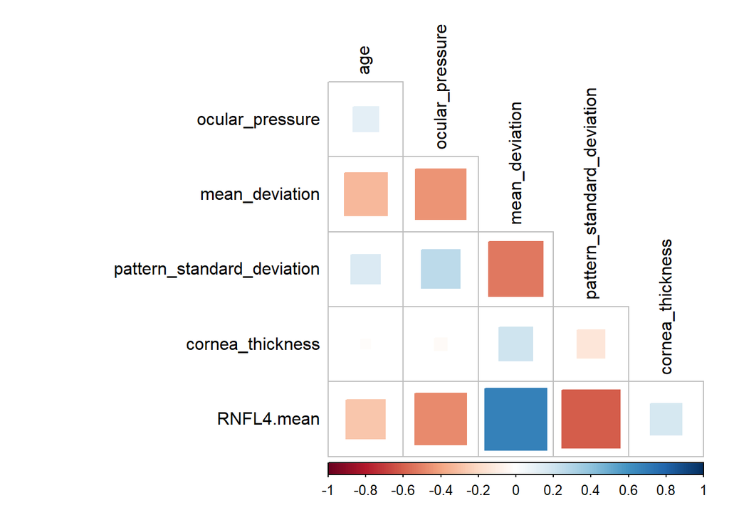

```r
corrplot(df_cont_corr,
         method = "square",
         type = "lower",
         diag = FALSE,
         tl.pos = "ld",
         tl.col = "black",
         tl.cex = 1)
```

The correlations between these continuous variables show that RNFL4.mean and mean_deviation are the most well correlated, with a Pearson correlation coefficient of ~0.679. The visualization above displays the correlation coefficients using both a red-blue color scale and by the size of the square within the box. I trimmed off the mirroring of the values, self-pairings, and changed the font color to black for better readability.

I’ll now repeat these analyses on the data after subsetting by disease state.

First I’ll do the non-glaucoma observations:

```r
df_healthy_cont <- df[which(df$glaucoma == 0), c(3,4,5,6,8,9)]
#Here I use the which function to take data only from rows where the value for the variable "glaucoma" is 0, indicating healthy samples
#Afterwards, visualization is the same as above.
df_healthy_cont_corr <- cor(df_healthy_cont)
kable(df_healthy_cont_corr)
```

|  | age | ocular_pressure | mean_deviation | pattern_standard_deviation | cornea_thickness | RNFL4.mean |
| --- | --- | --- | --- | --- | --- | --- |
| age | 1.0000000 | -0.0583037 | -0.1173733 | 0.3890849 | 0.1124222 | -0.1302326 |
| ocular_pressure | -0.0583037 | 1.0000000 | 0.0787444 | -0.1446542 | 0.4415463 | -0.1928512 |
| mean_deviation | -0.1173733 | 0.0787444 | 1.0000000 | -0.5698943 | 0.1100559 | 0.2415170 |
| pattern_standard_deviation | 0.3890849 | -0.1446542 | -0.5698943 | 1.0000000 | 0.0224184 | -0.1894434 |
| cornea_thickness | 0.1124222 | 0.4415463 | 0.1100559 | 0.0224184 | 1.0000000 | -0.1533524 |
| RNFL4.mean | -0.1302326 | -0.1928512 | 0.2415170 | -0.1894434 | -0.1533524 | 1.0000000 |

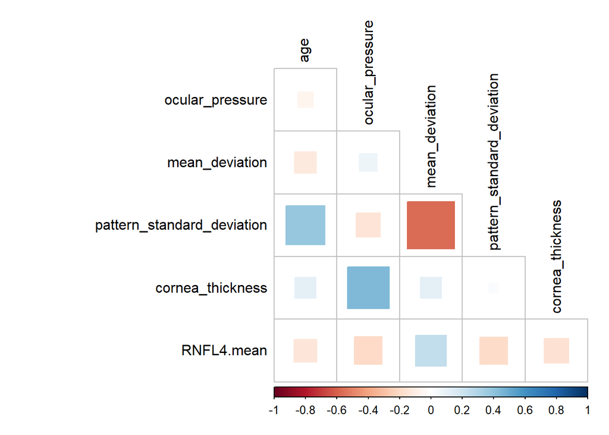

```r
corrplot(df_healthy_cont_corr,
         method = "square",
         type = "lower",
         diag = FALSE,
         tl.pos = "ld",
         tl.col = "black",
         tl.cex = 1)
```

In the healthy samples, mean deviation and pattern standard deviation are now the strongest correlation, being an anti-correlation with a value of -0.57. It is somewhat interesting that the dominant correlation changes here, although the biological implications of this are lost on me.

```r
df_disease_cont <- df[which(df$glaucoma == 1), c(3,4,5,6,8,9)]
#Same type of subsetting by row, except using a value of one, indicating glaucoma diagnosis.
df_disease_cont_corr <- cor(df_disease_cont)
kable(df_disease_cont_corr)
```

|  | age | ocular_pressure | mean_deviation | pattern_standard_deviation | cornea_thickness | RNFL4.mean |
| --- | --- | --- | --- | --- | --- | --- |
| age | 1.0000000 | -0.0043218 | -0.2875702 | -0.1363500 | -0.0369999 | -0.0818440 |
| ocular_pressure | -0.0043218 | 1.0000000 | -0.3013090 | -0.0328888 | -0.0350435 | -0.2628938 |
| mean_deviation | -0.2875702 | -0.3013090 | 1.0000000 | -0.2754665 | 0.1603014 | 0.5625957 |
| pattern_standard_deviation | -0.1363500 | -0.0328888 | -0.2754665 | 1.0000000 | -0.0495949 | -0.2814673 |
| cornea_thickness | -0.0369999 | -0.0350435 | 0.1603014 | -0.0495949 | 1.0000000 | 0.1882292 |
| RNFL4.mean | -0.0818440 | -0.2628938 | 0.5625957 | -0.2814673 | 0.1882292 | 1.0000000 |

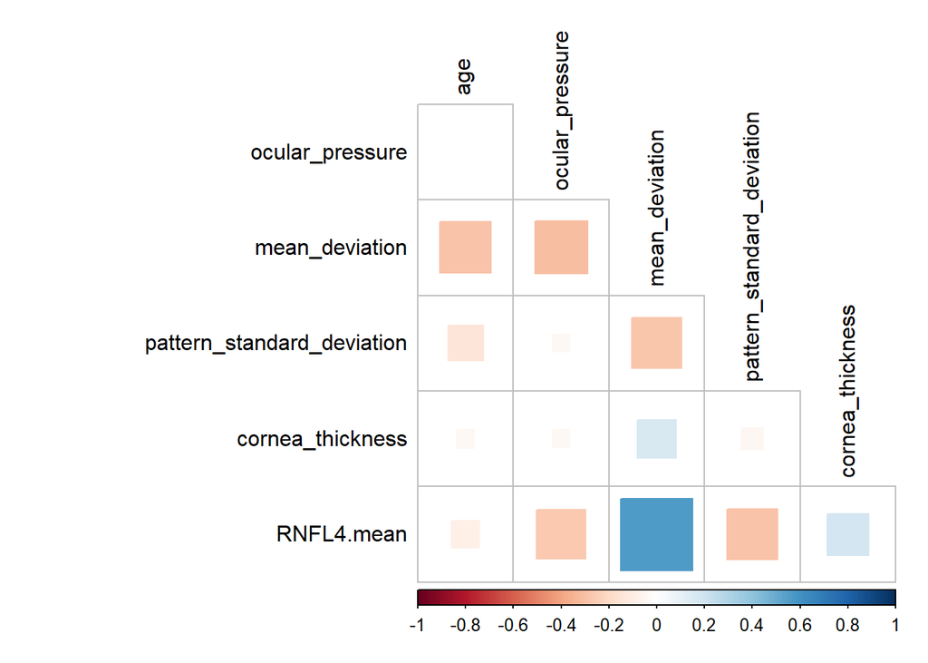

```r
corrplot(df_disease_cont_corr,
         method = "square",
         type = "lower",
         diag = FALSE,
         tl.pos = "ld",
         tl.col = "black")
```

In the disease state, mean_deviation and RNFL mean maintain the highest correlation coefficient, although the strength of the correlation weakens slightly having a value of only 0.56.